# EXIST 2019 IDM Analysis

R’sızlar

04 Eylül 2020

# 1 Introduction

We have 7 different datasets belonging to Intraday Market of EXIST. All of them are provided for a defined time period which is 2019.

[figure not shown]

## 1.1 Loading the Libraries

Throughout our analysis, we will make use of some well known R packages as tidyverse, ggplot2, lubridate, etc.

```r
library(tidyverse)
library(lubridate)
library(readr)
library(dplyr)
library(ggplot2)
library(knitr)
```

## 1.2 Loading Datasets

This analysis is made according to 7 different datasets from [Energy Exchange of Turkey (EXIST / EPIAS)](https://seffaflik.epias.com.tr/transparency/piyasalar/gip/gip-agirlikli-ortalama-fiyat.xhtml) .

```r
weighted_average_price <- read.csv("https://github.com/pjournal/boun01g-r-sizlar/blob/gh-pages/1idm-weighted-average-price-01012019-31122019.csv?raw=true")

matching_quantity <- read.csv("https://github.com/pjournal/boun01g-r-sizlar/blob/gh-pages/2IDMMatchingQuantity-01012019-31122019.csv?raw=true")

bid_prices <- read.csv("https://github.com/pjournal/boun01g-r-sizlar/blob/gh-pages/3IDMMinMaxBidPrices-01012019-31122019.csv?raw=true")

offer_prices <- read.csv("https://github.com/pjournal/boun01g-r-sizlar/blob/gh-pages/4IntradayMinMaxOfferPrices-01012019-31122019.csv?raw=true")

bid_offer_quantities <- read.csv("https://github.com/pjournal/boun01g-r-sizlar/blob/gh-pages/5BidOfferQuantities-01012019-31122019.csv?raw=true")

matching_price <- read.csv("https://github.com/pjournal/boun01g-r-sizlar/blob/gh-pages/6IntraDayMinMaxMatchingPrice-01012019-31122019.csv?raw=true")

trade_value <- read.csv("https://github.com/pjournal/boun01g-r-sizlar/blob/gh-pages/7IDMTradeValue-01012019-31122019.csv?raw=true")
```

# 2 Data Preprocessing

To make our data ready to analyze, we will do some rearrangements on our data which will also increase its reproducibility and repeatability. These rearrangements will include:

- Joining process of all 7 data
- Omission of some columns which we will not need to use
- Filtering of data due to necessities
- Date - Time information is converted to POSIXct format
- Adding of new columns such as Hour, Day of Week and Month

```r
alfa_data <- matching_quantity %>%
            inner_join(bid_prices, by = "Contract.Name") %>%
            inner_join(offer_prices, by = "Contract.Name") %>%
            inner_join(bid_offer_quantities, by = "Contract.Name") %>%
            inner_join(matching_price, by = "Contract.Name") %>%
            inner_join(trade_value, by = "Contract.Name") %>%
            select(-c("Contract.Type.y", "Contract.Type.x.x", "Contract.Type.y.y",
                      "Contract.Type.x.x.x", "Contract.Type.y.y.y", "Contract.Name")) %>%
            filter(Contract.Type.x == "Hourly") %>%
            select(-Contract.Type.x)

alfa_data %>%
  glimpse()
```

```
## Rows: 8,740
## Columns: 10
## $ Clearing.Quantity..MWh.      <chr> "331.20", "527.70", "196.70", "414.70"...
## $ Min.Bid.Price..TL.MWh.       <dbl> 5.00, 5.00, 41.00, 1.00, 1.00, 1.00, 1...
## $ Max..Bid.Price..TL.MWh.      <chr> "101.38", "97.55", "81.60", "45.00", "...
## $ Min..Offer.Price..TL.MWh.    <chr> "60.00", "93.82", "40.00", "4.00", "5....
## $ Max..Offer.Price..TL.MWh.    <chr> "100.39", "296.29", "81.60", "45.00", ...
## $ Bid.Quantity..MWh.           <chr> "392.50", "910.00", "576.70", "797.40"...
## $ Offer.Quantity..MWh.         <chr> "509.40", "664.20", "349.60", "552.90"...
## $ Min..Matching.Price..TL.MWh. <dbl> 60.00, 93.82, 41.05, 4.00, 5.00, 5.00,...
## $ Max..Matching.Price..TL.MWh. <dbl> 100.39, 97.55, 81.60, 45.00, 11.52, 11...
## $ Trade.Value..TL.             <chr> "33,182.96", "51,036.02", "15,652.36",...
```

```r
beta_data <- weighted_average_price %>%
  bind_cols(alfa_data)

beta_data %>%
  glimpse()
```

```
## Rows: 8,740
## Columns: 13
## $ Date                         <chr> "01.01.2019", "01.01.2019", "01.01.201...
## $ Hour                         <chr> "00:00", "01:00", "02:00", "03:00", "0...
## $ WAP..TL.MWh.                 <dbl> 100.23, 96.85, 80.25, 38.28, 11.67, 11...
## $ Clearing.Quantity..MWh.      <chr> "331.20", "527.70", "196.70", "414.70"...
## $ Min.Bid.Price..TL.MWh.       <dbl> 5.00, 5.00, 41.00, 1.00, 1.00, 1.00, 1...
## $ Max..Bid.Price..TL.MWh.      <chr> "101.38", "97.55", "81.60", "45.00", "...
## $ Min..Offer.Price..TL.MWh.    <chr> "60.00", "93.82", "40.00", "4.00", "5....
## $ Max..Offer.Price..TL.MWh.    <chr> "100.39", "296.29", "81.60", "45.00", ...
## $ Bid.Quantity..MWh.           <chr> "392.50", "910.00", "576.70", "797.40"...
## $ Offer.Quantity..MWh.         <chr> "509.40", "664.20", "349.60", "552.90"...
## $ Min..Matching.Price..TL.MWh. <dbl> 60.00, 93.82, 41.05, 4.00, 5.00, 5.00,...
## $ Max..Matching.Price..TL.MWh. <dbl> 100.39, 97.55, 81.60, 45.00, 11.52, 11...
## $ Trade.Value..TL.             <chr> "33,182.96", "51,036.02", "15,652.36",...
```

```r
Sys.setlocale("LC_TIME", "C")
```

```
## [1] "C"
```

```r
idm_data <- beta_data %>%
  mutate(Date.Time = as.POSIXlt(factor(Date), format="%d.%m.%y")) %>%
  mutate(Date.Time = update(Date.Time, year = 2019)) %>%
  mutate(Day.Week = wday(Date.Time,label = TRUE,week_start=1), Month = month(Date.Time),Hour = hour(Date.Time)) %>%
  select(-Date) %>%
  relocate(Date.Time,
           Hour,
           Day.Week,
           Month,
           WAP..TL.MWh.,
           Clearing.Quantity..MWh.,
           Min.Bid.Price..TL.MWh.,
           Max..Offer.Price..TL.MWh.,
           Bid.Quantity..MWh.,
           Offer.Quantity..MWh.,
           Min..Matching.Price..TL.MWh.,
           Max..Matching.Price..TL.MWh.,
           Trade.Value..TL.)

idm_data %>% glimpse()
```

```
## Rows: 8,740
## Columns: 15
## $ Date.Time                    <dttm> 2019-01-01, 2019-01-01, 2019-01-01, 2...
## $ Hour                         <int> 0, 0, 0, 0, 0, 0, 0, 0, 0, 0, 0, 0, 0,...
## $ Day.Week                     <ord> Tue, Tue, Tue, Tue, Tue, Tue, Tue, Tue...
## $ Month                        <dbl> 1, 1, 1, 1, 1, 1, 1, 1, 1, 1, 1, 1, 1,...
## $ WAP..TL.MWh.                 <dbl> 100.23, 96.85, 80.25, 38.28, 11.67, 11...
## $ Clearing.Quantity..MWh.      <chr> "331.20", "527.70", "196.70", "414.70"...
## $ Min.Bid.Price..TL.MWh.       <dbl> 5.00, 5.00, 41.00, 1.00, 1.00, 1.00, 1...
## $ Max..Offer.Price..TL.MWh.    <chr> "100.39", "296.29", "81.60", "45.00", ...
## $ Bid.Quantity..MWh.           <chr> "392.50", "910.00", "576.70", "797.40"...
## $ Offer.Quantity..MWh.         <chr> "509.40", "664.20", "349.60", "552.90"...
## $ Min..Matching.Price..TL.MWh. <dbl> 60.00, 93.82, 41.05, 4.00, 5.00, 5.00,...
## $ Max..Matching.Price..TL.MWh. <dbl> 100.39, 97.55, 81.60, 45.00, 11.52, 11...
## $ Trade.Value..TL.             <chr> "33,182.96", "51,036.02", "15,652.36",...
## $ Max..Bid.Price..TL.MWh.      <chr> "101.38", "97.55", "81.60", "45.00", "...
## $ Min..Offer.Price..TL.MWh.    <chr> "60.00", "93.82", "40.00", "4.00", "5....
```

```r
idm_data$Clearing.Quantity..MWh. <- as.numeric(idm_data$Clearing.Quantity..MWh.)
idm_data$Max..Bid.Price..TL.MWh. <- as.numeric(idm_data$Max..Bid.Price..TL.MWh.)
idm_data$Max..Offer.Price..TL.MWh. <- as.numeric(idm_data$Max..Offer.Price..TL.MWh.)
idm_data$Bid.Quantity..MWh. <- as.numeric(idm_data$Bid.Quantity..MWh.)
idm_data$Offer.Quantity..MWh. <- as.numeric(idm_data$Offer.Quantity..MWh.)
idm_data$Trade.Value..TL. <- as.numeric(gsub(",", "", idm_data$Trade.Value..TL.))
idm_data[is.na(idm_data)] <- 0
```

# 3 Exploratory Data Analysis

## 3.1 IDM Matching Quantity

In this part we made monthly comparison of IDM matching quantities for 2019.

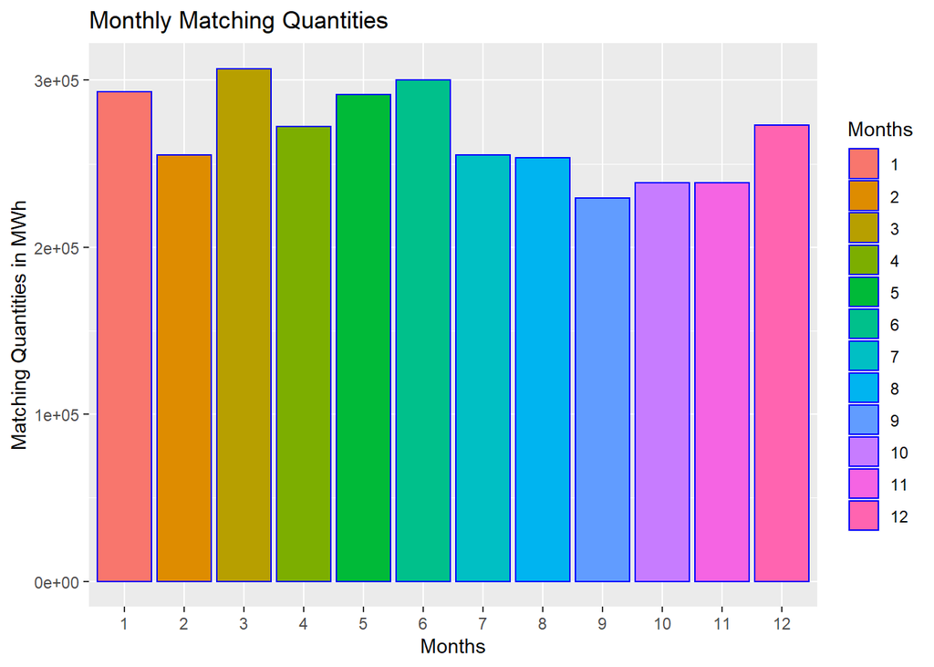

```r
new_dataa <- idm_data %>% select(Month,Clearing.Quantity..MWh.)
monthly_matching_quantity <- new_dataa %>% group_by(Month) %>% summarise(Clearing.Quantity..MWh.= sum(Clearing.Quantity..MWh.))

ggplot(data=monthly_matching_quantity,aes(x=as.factor(Month),y=Clearing.Quantity..MWh.,fill=as.factor(Month)))+
labs(x="Months", y="Matching Quantities in MWh", color="Months", title = "Monthly Matching Quantities") +
  geom_bar(stat='identity',width=0.9,color='blue') +
  guides(fill=guide_legend(title="Months"))
```

As seen above, the Matching Quantity has a peak in March and a minimum point in September.

## 3.2 IDM Daily Matching Quantities

In this part we made daily comparison of IDM matching quantities for 2019.

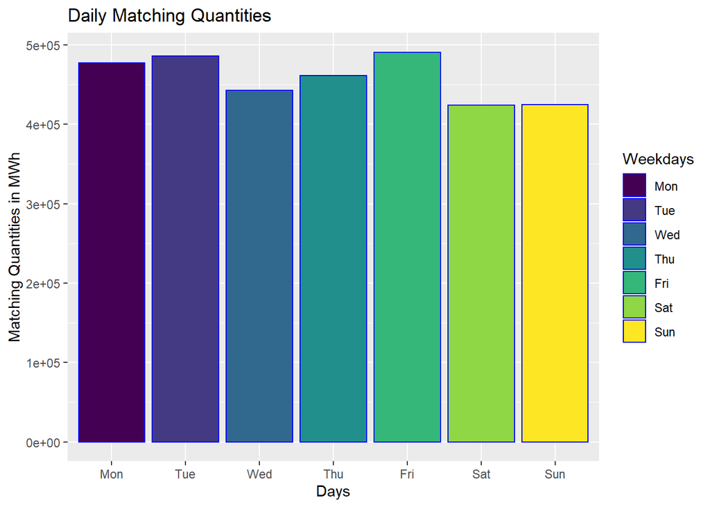

```r
new_dataa2 <- idm_data %>% select(Clearing.Quantity..MWh.,Day.Week)
daily_matching_quantity <- new_dataa2 %>% group_by(Day.Week) %>% summarise(Clearing.Quantity..MWh.= sum(Clearing.Quantity..MWh.))

ggplot(data=daily_matching_quantity,aes(x=as.factor(Day.Week),y=Clearing.Quantity..MWh.,fill=as.factor(Day.Week)))+
labs(x="Days", y="Matching Quantities in MWh", color="Days", title = "Daily Matching Quantities") +
  geom_bar(stat='identity',width=0.9,color='blue') +
  guides(fill=guide_legend(title="Weekdays"))
```

According to the plot above, there is no significant differences in the Matching Quantities in the weekdays. However, a little drop can be seen in the weekend.

## 3.3 IDM Monthly Weighted Average Prices

In this part we made monthly comparison of IDM weighted average prices for 2019.

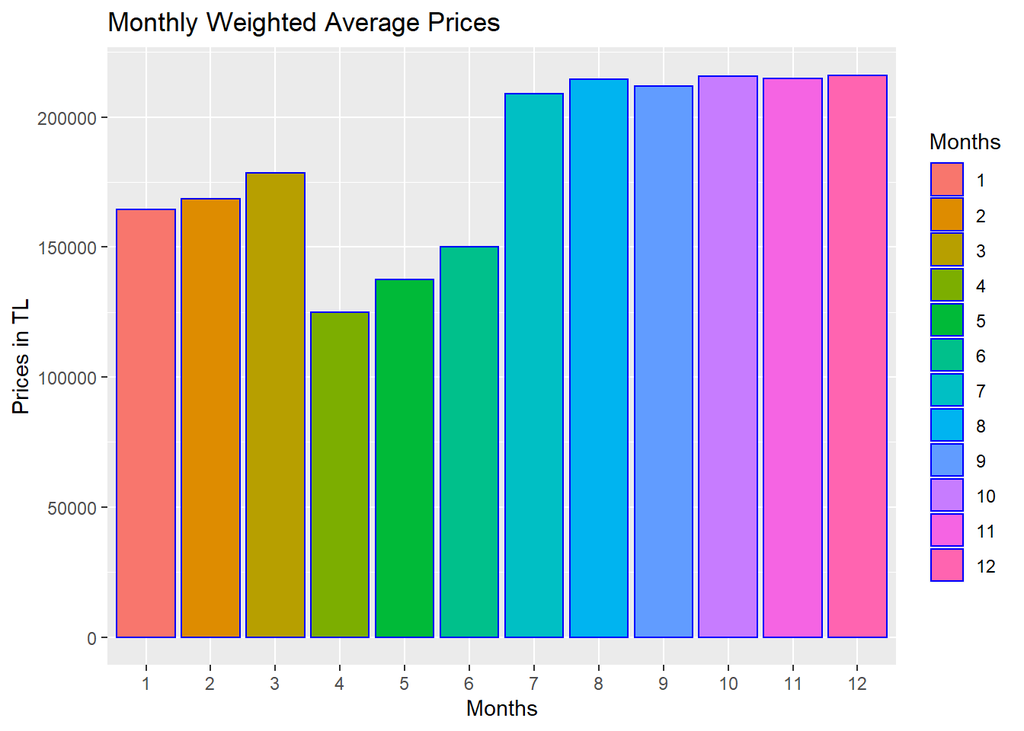

```r
new_dataa3 <- idm_data %>% select(WAP..TL.MWh.,Month)
monthly_weighted_average_prices <- new_dataa3 %>% group_by(Month) %>% summarise(WAP..TL.MWh.= sum(WAP..TL.MWh.))

a <- ggplot(monthly_weighted_average_prices,aes(x=as.factor(Month),y=WAP..TL.MWh.,fill=as.factor(Month)))+
labs(x="Months", y="Prices in TL", color="Months", title = "Monthly Weighted Average Prices") +
  geom_bar(stat='identity',width=0.9,color='blue') +
  guides(fill=guide_legend(title="Months"))

show(a)
```

As seen above, in the second half of the year Monthly Weighted Average Prices went up. Besides, after first quarter, there is a significant drop in the prices.

## 3.4 IDM Monthly Offer Quantities

In this part we made monthly comparison of IDM monthly offer quantities for 2019.

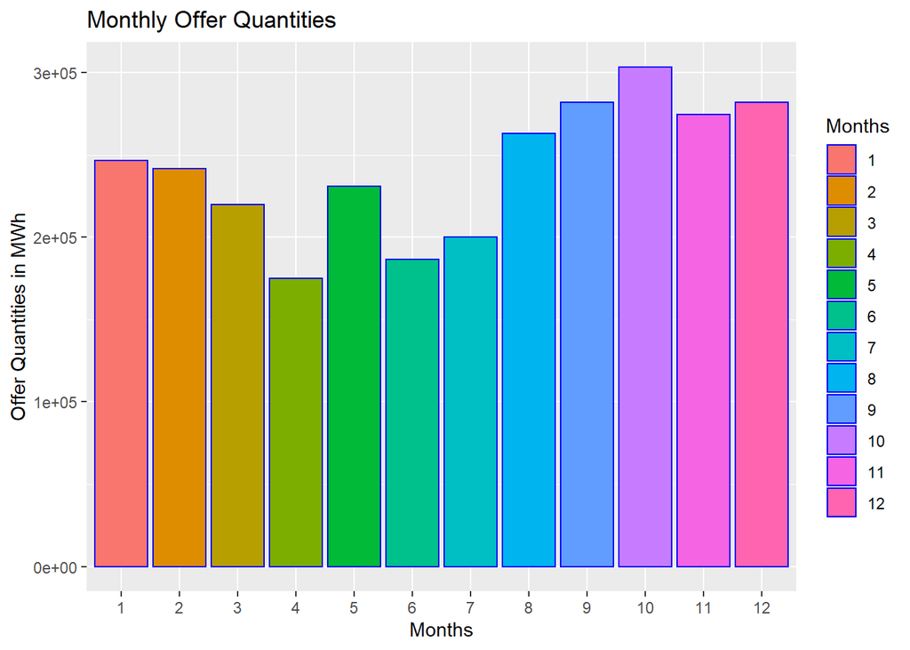

```r
new_dataa4 <- idm_data %>% select(Offer.Quantity..MWh.,Month)
monthly_offer_quantities <- new_dataa4 %>% group_by(Month) %>% summarise(Offer.Quantity..MWh.= sum(Offer.Quantity..MWh.))

ggplot(monthly_offer_quantities,aes(x=as.factor(Month),y=Offer.Quantity..MWh.,fill=as.factor(Month)))+
labs(x="Months", y="Offer Quantities in MWh", color="Months", title = "Monthly Offer Quantities") +
  geom_bar(stat='identity',width=0.9,color='blue') +
  guides(fill=guide_legend(title="Months"))
```

It can be seen that there is a reduction in the offer quantities in the beginning of the year till May. After that, we can see significantly higher offer quantities in the last months.

## 3.5 IDM Monthly Offer and Matching Quantities

In this part we made monthly comparison of IDM offer and matching quantities for 2019.

[figure not shown]

```r
new_dataa5 <- idm_data %>% select(Month,Clearing.Quantity..MWh.,Offer.Quantity..MWh.)
monthly_offer_and_matching_quantities <- new_dataa5 %>% group_by(Month) %>% summarise(Clearing.Quantity..MWh.= sum(Clearing.Quantity..MWh.),Offer.Quantity..MWh.=sum(Offer.Quantity..MWh.))

monthly_offer_and_matching_quantities_longer <-
monthly_offer_and_matching_quantities %>%
  ungroup() %>%
  pivot_longer(cols=c(Clearing.Quantity..MWh., Offer.Quantity..MWh.), names_to="Types", values_to="Quantities") %>%
  select(Month,Types,Quantities)

ggplot(monthly_offer_and_matching_quantities_longer, aes(x=Month, y=Quantities, fill=Types)) +
            scale_fill_manual(values=c("coral3", "darkslateblue")) +
            theme_minimal() +
            geom_bar(stat="identity", position="dodge") +
            ggtitle("Average MCP vs SMP Prices per Day of Week") +
            theme(axis.text.x = element_text(angle = 45), legend.position = "top")
```

## 3.6 IDM Monthly Maximum Bid and Matching Prices

We compared IDM maximum bid, and matching prices for 2019.

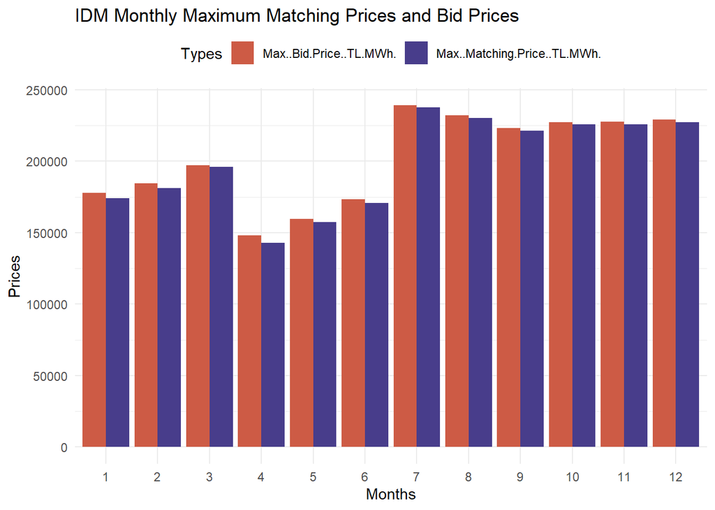

```r
new_dataa9 <- idm_data %>% select(Month,Max..Matching.Price..TL.MWh., Max..Bid.Price..TL.MWh.)
monthly_max_offer_and_matching_bid_prices <- new_dataa9 %>% group_by(Month) %>% summarise(Max..Matching.Price..TL.MWh.=sum(Max..Matching.Price..TL.MWh.), Max..Bid.Price..TL.MWh.=sum( Max..Bid.Price..TL.MWh.))

monthly_max_offer_and_matching_bid_prices_longer <-
monthly_max_offer_and_matching_bid_prices %>%
  ungroup() %>%
  pivot_longer(cols=c( Max..Matching.Price..TL.MWh.,Max..Bid.Price..TL.MWh.), names_to="Types", values_to="Prices") %>%
  select(Month,Types,Prices)

ggplot(monthly_max_offer_and_matching_bid_prices_longer, aes(x=as.factor(Month), y=Prices, fill=Types)) +
            scale_fill_manual(values=c("coral3", "darkslateblue")) +
            theme_minimal() +
            geom_bar(stat="identity", position="dodge") +
            ggtitle("IDM Monthly Maximum Matching Prices and Bid Prices") +
            theme(axis.text.x = element_text(angle = 0), legend.position = "top")+
            labs(x="Months")
```

According to our analysis shown above, in the second quarter there is a significant drop in both prices. Moreover, to compare prices to each other, we can see that maximum bid prices are slightly higher than maximum matching prices.

## 3.7 IDM Monthly Trading Volume

In this part we made monthly comparison of IDM traing volume for 2019.

[figure not shown]

```r
new_dataa6 <- idm_data %>% select(Month,Trade.Value..TL.)

monthly_trading_volume <- new_dataa6 %>%
  group_by(Month) %>%
  summarise(Trade.Value..TL.= sum(Trade.Value..TL.))

ggplot(data=monthly_trading_volume,aes(x=as.factor(Month),y=Trade.Value..TL., group = 1)) +
  geom_line() +
  geom_point() +
  labs(
    title = "Monthly Trading Volume for 2019",
    x = "Months",
    y = "Quantities in MWh"
  )
```